# RSV (AREXVY) - Product use issue

OpenSourcePV

Data Lock Point: Data contains VAERS reports processed as of 2023_11_24 (Year_Month_Day). Flag NEW was defined against reports processed as of 2023_10_27.

# 1 Quantitative Signal status

## 1.1 Disproportionality

The vaccine-event combination “RSV (AREXVY) - Product use issue” was **a signal of disproportionate reporting** with an EB05 value of 28.26.

The threshold for being flagged as a signal of disproportionate reporting is an EB05>=2 meaning that there there is a 95% probability that the reporting of Product use issue was at least twice post exposure to RSV (AREXVY) than post all vaccines. Under the assumption of no causality between RSV (AREXVY) and Product use issue and no bias it would have been expected to observe an EBGM of 1.

It means that the quantified causality criterion of strength of association is **met**.

*It is to be noted that the nature of the spontaneous report does not provide reliable estimates of the strength of association (whatever the choice of the disproportionality method) and that some reporting bias or difference in demographic characteristics might explain the (un)observed disproportion*.

## 1.2 Time-to-onset

The vaccine-event combination “RSV (AREXVY) - Product use issue” was **not a signal of unexpected time-to-onset distribution** with a p-value of the two-sample Kolmogorov-Smirnov test being 0.9999997 and distance between the two empirical cumulative distributions being of 4.7101172%.

The threshold for being flagged as a signal of unexpected time-to-onset distribution is a P-value of the two-sample Kolmogorov-Smirnov test <0.001 and a distance between the two empirical distributions larger than 20%. Under the assumption of no causality and no bias, it would have been expected that the time-to-onset distribution for “Product use issue” would have been the same post RSV (AREXVY) than post other vaccines. The two-sample Kolmogorov-Smirnov tests this hypothesis.

It means that the quantified causality criterion of temporality is **not met**.

*It is to be noted that the nature of the spontaneous report does not provide reliable estimates of the temporal relationship between the exposure and the occurrence of the events as there is the reporting bias over time: the latter the event occurs after exposure, the less chance it has to be reported. Other biases could distort the reported time-to-onset distribution (media attention, etc.)*

## 1.3 Overall

Based on the screening of the Empirical Bayes Geometric Mean (EBGM) and the screening of the time-to-onset distribution,the vaccine-event combination “RSV (AREXVY) - Product use issue” is **considered as quantitative signal**.

# 2 Signal History

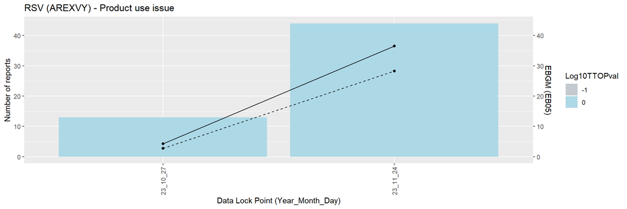

# 3 Case series

## 3.1 Seriousness

A total of 44 reports of Product use issue were received post exposure to RSV (AREXVY). Among them:

- 0 (0.0 %) were fatal cases.
- 0 (0.0 %) were life threatening cases.
- 0 (0.0 %) were hospitalized cases.
- 0 (0.0 %) were emergency room cases.
- 0 (0.0 %) were cases with disabilies.

31 new cases were received since last data refresh.

## 3.2 Demographic characteristics

44 cases of Product use issue post RSV (AREXVY) were reported in VAERS:

- Among them, there were 43 (97.7%) female cases and 0 (0%) male cases while the overall female:male ratio is 69:26%.
- The mean (median) age for patients presenting symptoms of Product use issue was 34 (33) years while the overall mean (median) age was 71 (71) years.
- The top 5 contributing US states for patients presenting symptoms of Product use issue were NY ( 11.4 %) , CA ( 9.1 %) , KY ( 9.1 %) , NA ( 9.1 %) , FL ( 6.8 %) while overall the top 5 of contributing US states are NA ( 11.1 %) , FL ( 10.2 %) , CA ( 8.5 %) , NY ( 6.1 %) , TX ( 4.2 %)

# 4 Listing of the cases

Narratives can be made visible clicking on the ⊕ symbol.

|  | VAERS_ID | Sex/Age (Years) | Receipt Date | Seriousness status | List of symptoms | new | SYMPTOM_TEXT |
| --- | --- | --- | --- | --- | --- | --- | --- |
| &oplus; | 2697061 | F/36 | 10/17/2023 |  | Exposure during pregnancy, Product use issue | No | Pt came to clinic requesting a RSV vaccine Clinic only has Arexvy in stock LPN gave Arexvy Pt is pregnant and 36 years old Unsure how far along Pt is with pregnancy |
| &oplus; | 2699140 | F/32 | 10/20/2023 |  | Exposure during pregnancy, Product use issue, Wrong product administered | No | Pt is 34 weeks pregnant and came in for new RSV vaccine Abrysvo but received Arexvy in error There are no contraindications of use for Arexvy in pregnant patients but it is not approved for administra… |
| &oplus; | 2699228 | F/26 | 10/20/2023 |  | Exposure during pregnancy, No adverse event, Product use issue | No | Patient is 36 weeks pregnant has not had any adverse event so far We are putting in a VEARS due to the fact AREXVY has not been studied to be safe in pregnant women only the ABRYSVO She spoke with her… |
| &oplus; | 2699277 | F/NA | 10/20/2023 |  | Exposure during pregnancy, No adverse event, Product administered to patient of inappropriate age, Product use issue | No | Inappropriate age at vaccine administration Pregnant women was accidently administered Arexvy This non serious prospective pregnancy case was reported by a nurse via sales rep and described the occurr… |
| &oplus; | 2699369 | F/35 | 10/20/2023 |  | Delivery, Exposure during pregnancy, Product administered to patient of inappropriate age, Product use issue, Wrong product administered | No | Arexvy was administered when she was 36 weeks pregnant Arexvy is not approved for patients under 60 years old Patient was given Arexvy instead of Abrysvo This non serious retrospective pregnancy case … |
| &oplus; | 2699389 | F/38 | 10/20/2023 |  | Exposure during pregnancy, Product administered to patient of inappropriate age, Product use issue, Wrong product administered | No | Arexvy was administered to a pregnant patient instead of the Pfizer brand RSV vaccine that is indicated for pregnant patients Inappropriate Age at Vaccine Administration This non serious prospective p… |
| &oplus; | 2699391 | F/NA | 10/20/2023 |  | Exposure during pregnancy, Product administered to patient of inappropriate age, Product use issue, Wrong product administered | No | administration of Arexvy to a pregnant woman 35 years old patient recieved Arexvy administration of Arexvy to a pregnant woman instead of the RSV vaccine from Pfizer ABRYSVO This non serious prospecti… |
| &oplus; | 2700206 | F/32 | 10/23/2023 |  | Exposure during pregnancy, Product use issue, Wrong product administered | No | Pt was 34 weeks pregnant gave Arexvy vaccine instead of Abrysbo vaccine |
| &oplus; | 2700279 | F/39 | 10/23/2023 |  | Exposure during pregnancy, Product use issue, Wrong product administered | No | Pregnant patient was given Arexvy instead of Abrysvo |
| &oplus; | 2700450 | F/32 | 10/24/2023 |  | Exposure during pregnancy, Product administered to patient of inappropriate age, Product use issue, Wrong product administered | No | Drug Exposure During Pregnancy patient received Arexvy by mistake yesterday 32 years patient received Arexvy This non serious prospective pregnancy case was reported by a pharmacist via call center re… |

[output cut: 34 more lines]

# 5 Disclaimer

This analysis is exploratory only and authors cannot be held responsible for any decision made using these data. It is important to distinguish quantitative signals such as disproportionate reporting, unexpected time-to-onset patterns or cluster from safety signals. Only a qualitative review using multiple data source (literature, clinical trials, etc.) and multiple causality criteria assessment could qualify quantitative signals into safety signals.